# (Ford GoBike ,tripdata)

## by (Mohamed Abdallah)

## Preliminary Wrangling

> This dataset is known as Ford GoBike Dataset that includes information about individual rides make in a bike sharing system covering the greater New York. In this investigation, I wanted to find characteristics and common trends in the first quartile in 2020.

> laod the first 3 monthes of the 2020

### What is the structure of your dataset?

> 3455883 rows!  
> 15 column

### What is/are the main feature(s) of interest in your dataset?

> I interested in finding out what features are best for predicting the trip duration !

### What features in the dataset do you think will help support your investigation into your feature(s) of interest?

> I expect that the (usertype ,birth year , gender ) will support my investigation !

## Univariate Exploration

> in this section, I will investigate distributions of individual variables.

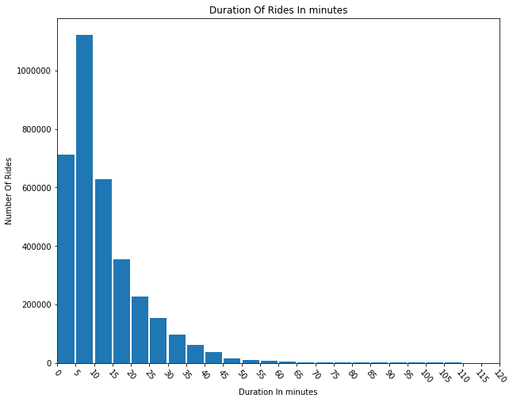

```python
#Distribution of duration of rides
data = df['tripduration_min']
binsize = 5
bins = np.arange(0,data.max()+binsize,binsize)
plt.figure(figsize=(10,8))
plt.hist(data , bins = bins , rwidth=.9)
plt.xlim(0,120)
plt.xticks(np.arange(0, 125,5),rotation=-50)
plt.title('Duration Of Rides In minutes')
plt.xlabel('Duration In minutes')
plt.ylabel('Number Of Rides');
```

> From the statistics, we can observe that there are outliers in the duration of rides due to the maximum duration being an extremely high number. By looking at the graph we can conclude that the majority of the rides are under 15 minutes.

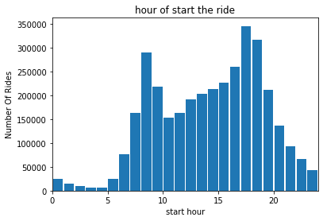

```python
data = df['starttime'].dt.hour
binsize = 1
bins = np.arange(0, 25, binsize)
plt.hist(data , bins = bins , rwidth=.9)
plt.xlim(0,24)
plt.title('hour of start the ride')
plt.xlabel('start hour')
plt.ylabel('Number Of Rides');
plt.show()
```

> As expected the distribution is bimodal. The two peaks are during the normal rush hours of a day. The first between the hours of 7AM and 10AM. And the second peak is between the hours of 5PM and 7PM.  
> and we cncloud that the first peak when the peaple are going to work and second peak when they come back.

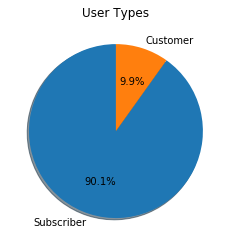

```python
#Distribution of type of users
data = df['usertype'].value_counts()/df['usertype'].value_counts().sum()
plt.pie(data, labels = data.index, autopct='%1.1f%%', shadow = 'True' , startangle = 90)
plt.title('User Types');
```

> We can observe that almost 9/10 of the users are subscribers.

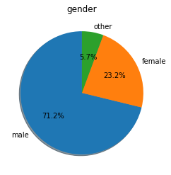

```python
#Distribution of type of users
data = df['gender'].value_counts()/df['gender'].value_counts().sum()
gender_f = plt.pie(data, labels = df.gender.value_counts().index, autopct='%1.1f%%', shadow = 'True' , startangle = 90)
plt.title('gender');
```

> We can observe that 7/10 are male , 2.3/10 are female and 5.7 are other.

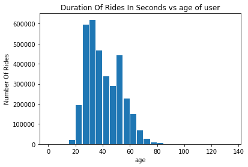

```python
data = df['age']
binsize = 5
bins = np.arange(0, df['age'].max()+binsize, binsize)
plt.hist(data ,bins=bins, rwidth=.9)
# plt.xlim(0,24)
plt.title('Duration Of Rides In Seconds vs age of user')
plt.xlabel('age')
plt.ylabel('Number Of Rides');
plt.show()
```

### Discuss the distribution(s) of your variable(s) of interest. Were there any unusual points? Did you need to perform any transformations?

> I had to convert from birht year to age to know the excacly the age of the users .

### Of the features you investigated, were there any unusual distributions? Did you perform any operations on the data to tidy, adjust, or change the form of the data? If so, why did you do this?

> I convert to age to deal with the age directry to determin if the age effect the ride duration or not !

## Bivariate Exploration

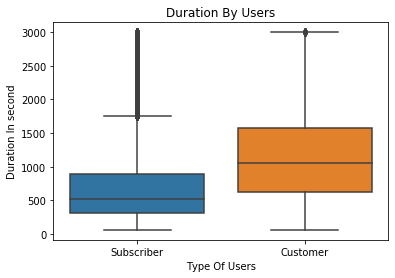

```python
#Distribution of the duration by users
majority = df[df['tripduration'] < 3000]
sb.boxplot(data =majority , y='tripduration', x='usertype') #,palette="Set3"
plt.title('Duration By Users')
plt.ylabel('Duration In second')
plt.xlabel('Type Of Users');
```

> The distribution shows us that customers on average take a longer trip than subscribers.

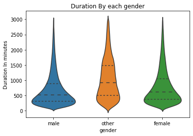

```python
#Distribution of the duration by each gender
majority = df[df['tripduration_min'] < 50]
sb.violinplot(data =majority , y='tripduration', x='gender',inner='quartile')
plt.title('Duration By each gender')
plt.ylabel('Duration In minutes')
plt.xlabel('gender');
```

> The distribution shows us that other-gender on average take a longer trip than male,female.

### Talk about some of the relationships you observed in this part of the investigation. How did the feature(s) of interest vary with other features in the dataset?

> From the distribution I have seen that the subscribers on average take shorter trip. A reason might be because these subscribers are people that work in the city and only take the bike for the convenience. Whereas a customer might be tourists .

### Did you observe any interesting relationships between the other features (not the main feature(s) of interest)?

> NO !

## Multivariate Exploration

> In this section I will create plots of three or more variables to investigate the data even further.

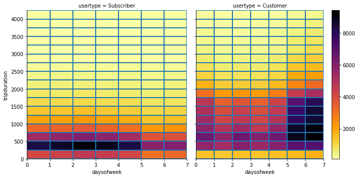

```python
#Distribution of the duration per trip in the week by subscribers
xbin = np.arange(0,7+1,1)
ybin = np.arange(0,4200+250,250)

g = sb.FacetGrid (data = df , col='usertype', height=5)
g.map(plt.hist2d, 'daysofweek', 'tripduration', cmin=0.5, cmap = 'inferno_r', bins=[xbin,ybin])
plt.colorbar();
```

> From this heatmap we can similarities between customers and subscribers.as expected the customers take more time in weekend and that proved that he probably would be a tourist

### Talk about some of the relationships you observed in this part of the investigation. Were there features that strengthened each other in terms of looking at your feature(s) of interest?

> We have seen that customers take longer rides from subscribers. Because most customers are tourists and will travel longer distances to the see the city.!